# QuantifiedSelf

Jay Urbain

September 26, 2015

### Introduction

> Using devices such as Jawbone Up, Nike FuelBand, and Fitbit it is now possible to collect a large amount of data about personal activity relatively inexpensively. These type of devices are part of the quantified self movement – a group of enthusiasts who take measurements about themselves regularly to improve their health, to find patterns in their behavior, or because they are tech geeks. One thing that people regularly do is quantify how much of a particular activity they do, but they rarely quantify how well they do it.

> In this project, we will use data from accelerometers on the belt, forearm, arm, and dumbell of 6 participants to predict the manner in which they did the exercise. [Reference](http://groupware.les.inf.puc-rio.br/har#ixzz3msAKESdA)

A Random Forest classification model using 30 trees is developed to predict the following classes with $99.17$% accuracy:

- A: unilateral Dumbbell Biceps Curl
- B: classthrowing the elbows to the front
- C: lifting the dumbbell only halfway
- D: lowering the dumbbell only halfway
- E: throwing the hips to the front

*Ugulino, W.; Cardador, D.; Vega, K.; Velloso, E.; Milidiu, R.; Fuks, H. Wearable Computing: Accelerometers’ Data Classification of Body Postures and Movements. Proceedings of 21st Brazilian Symposium on Artificial Intelligence, 2012.*

### Load libraries and data

```r
library(caret)
library(randomForest)
library(rpart)
library(rpart.plot)
```

```r
training <- read.csv("./data/pml-training.csv", na.strings=c("NA",""))
testing <- read.csv("./data/pml-testing.csv", na.strings=c("NA",""))
dim(training)
```

```
## [1] 19622   160
```

```r
dim(testing)
```

```
## [1]  20 160
```

Unprocessed data:

- Training data: n=19622, p=160 variables.
- Testing data: n=20, p=160 variables.
- *classe* variable is the respoonse we are trying to predict.

### Data preprocessing

- Remove column attributes that will not be helpful for prediction: index, timestamp, and name
- Remove column attributes with missing values: NA’s
- Verify dimensions of resulting cleansed data and validation test sets

```r
# Exclude index, timestamp, and name column's
names(training)[1:7]
```

```
## [1] "X"                    "user_name"            "raw_timestamp_part_1"
## [4] "raw_timestamp_part_2" "cvtd_timestamp"       "new_window"
## [7] "num_window"
```

```r
trainingP1<-training[, 8:160]
testingP1<-testing[, 8:160]

# Exclude columns with NA's from training and test sets
trainingP2<-trainingP1[, apply(is.na(trainingP1),2,sum) == 0]
classe<-trainingP2$classe
trainingP2 <- trainingP2[, sapply(trainingP2, is.numeric)]
trainingP2$classe<-classe
dim(trainingP2)
```

```
## [1] 19622    53
```

```r
testingP2<-testingP1[, apply(is.na(testingP1),2,sum) == 0]
classe<-testingP2$classe
testingP2 <- testingP2[, sapply(testingP2, is.numeric)]
testingP2$classe<-classe
dim(testingP2)
```

```
## [1] 20 53
```

Processed data:

- Training data: n=19622, p=53 variables.
- Testing data: n=20, p=53 variables.

### Partition training data into train and test sets

```r
set.seed(3570)
trainPartition<-createDataPartition(y=trainingP2$classe, p=0.70, list=FALSE)
trainingIn<-trainingP2[trainPartition,]
testingIn<-trainingP2[-trainPartition,]
```

### Predictive model

Build a Random Forest classification model for activity recognition prediction.

- Random forests are an ensemble learning method that operate by constructing a multitude of decision trees at training time and outputting the class that is the mode of the classes (classification) or mean prediction (regression) of the individual trees.
- Random forests correct for decision trees’ habit of overfitting to their training set, i.e. they are robust to correlated covariates and outliers.
- 5-fold cross validation was used when applying the algorithm.
- 30 trees was used for our final model. See the Appendix for a table and plot RF accuracies for a number of decision trees. Using larger numbers of trees increases risk of overfitting the data for obtaining only marginal increases in accuracy.

```r
mRF <- train(classe ~ ., data=trainingIn, method="rf",
                 trControl=trainControl(method="cv", 5),
                 ntree=30)
mRF
```

```
## Random Forest
##
## 13737 samples
##    52 predictor
##     5 classes: 'A', 'B', 'C', 'D', 'E'
##
## No pre-processing
## Resampling: Cross-Validated (5 fold)
## Summary of sample sizes: 10989, 10990, 10989, 10991, 10989
## Resampling results across tuning parameters:
##
##   mtry  Accuracy   Kappa      Accuracy SD  Kappa SD
##    2    0.9858048  0.9820417  0.002572751  0.003255208
##   27    0.9903182  0.9877523  0.002918621  0.003692611
##   52    0.9835489  0.9791878  0.003452890  0.004370001
##
## Accuracy was used to select the optimal model using  the largest value.
## The final value used for the model was mtry = 27.
```

### Performance evaluation

- Predict classification on *training* test set
- Compute model *accuracy* and *out of sample error*

```r
# prediction classifications on test set
predictRF <- predict(mRF, testingIn)
confusionMatrix(testingIn$classe, predictRF)
```

```
## Confusion Matrix and Statistics
##
##           Reference
## Prediction    A    B    C    D    E
##          A 1671    3    0    0    0
##          B    7 1126    5    1    0
##          C    0    4 1017    5    0
##          D    0    3   17  944    0
##          E    0    0    1    3 1078
##
## Overall Statistics
##
##                Accuracy : 0.9917
##                  95% CI : (0.989, 0.9938)
##     No Information Rate : 0.2851
##     P-Value [Acc > NIR] : < 2.2e-16
##
##                   Kappa : 0.9895
##  Mcnemar's Test P-Value : NA
##
## Statistics by Class:
##
##                      Class: A Class: B Class: C Class: D Class: E
## Sensitivity            0.9958   0.9912   0.9779   0.9906   1.0000
## Specificity            0.9993   0.9973   0.9981   0.9959   0.9992
## Pos Pred Value         0.9982   0.9886   0.9912   0.9793   0.9963
## Neg Pred Value         0.9983   0.9979   0.9953   0.9982   1.0000
## Prevalence             0.2851   0.1930   0.1767   0.1619   0.1832
## Detection Rate         0.2839   0.1913   0.1728   0.1604   0.1832
## Detection Prevalence   0.2845   0.1935   0.1743   0.1638   0.1839
## Balanced Accuracy      0.9976   0.9942   0.9880   0.9933   0.9996
```

```r
#compute model accuracy
accuracy <- postResample(predictRF, testingIn$classe)
accuracy
```

```
##  Accuracy     Kappa
## 0.9916737 0.9894674
```

```r
#compute out of sample error (oose)
oose <- 1 - as.numeric(confusionMatrix(testingIn$classe, predictRF)$overall[1])
oose
```

```
## [1] 0.008326253
```

Prediction estimates:

- Accuracy: $99.17$%
- Out-of-sample error: $0.83$%.

### Model prediction on validation data set

- Estimate model performance on the validation set, i.e., the original test set.

```r
predictRF <- predict(mRF, testingP2[, -length(names(testingP2))] )
predictRF
```

```
##  [1] B A B A A E D B A A B C B A E E A B B B
## Levels: A B C D E
```

```r
# save predictions
if (!file.exists("./answers")) {
  dir.create("./answers")
}
pml_write_files = function(x){
  n = length(x)
  for(i in 1:n){
    filename = paste0("./answers/problem_id_",i,".txt")
    write.table(x[i],file=filename,quote=FALSE,row.names=FALSE,col.names=FALSE)
  }
}
pml_write_files(paste(predictRF))
```

### Appendix: Variable importance for Random Forest Model

> Random Forest from the R package: “For each tree, the prediction accuracy on the out-of-bag portion of the data is recorded. Then the same is done after permuting each predictor variable. The difference between the two accuracies are then averaged over all trees, and normalized by the standard error. For regression, the MSE is computed on the out-of-bag data for each tree, and then the same computed after permuting a variable. The differences are averaged and normalized by the standard error. If the standard error is equal to 0 for a variable, the division is not done.” Reference: http://topepo.github.io/caret/varimp.html

```r
mRFImp <- varImp(mRF, scale = FALSE)
mRFImp
```

```
## rf variable importance
##
##   only 20 most important variables shown (out of 52)
##
##                      Overall
## roll_belt             1363.8
## pitch_forearm          785.0
## yaw_belt               779.9
## pitch_belt             681.2
## roll_forearm           679.2
## magnet_dumbbell_y      586.1
## magnet_dumbbell_z      573.7
## accel_dumbbell_y       319.1
## roll_dumbbell          293.5
## accel_forearm_x        255.0
## accel_dumbbell_z       248.5
## magnet_dumbbell_x      232.8
## magnet_belt_z          210.2
## magnet_forearm_z       210.1
## magnet_belt_y          208.4
## accel_belt_z           206.5
## gyros_belt_z           196.7
## total_accel_dumbbell   195.9
## yaw_arm                193.1
## magnet_belt_x          169.6
```

### Appendix: Basic Decision Tree Dendogram

Build a basic decision tree model to visualize decision parameters in a dendogram. In the basic decistion tree model, the order of selection is similar to the variable importance calculated for the Random Forest. The Random Forest uses a larger number of parameters and generates a larger number of finer granulatiry classification leafs.

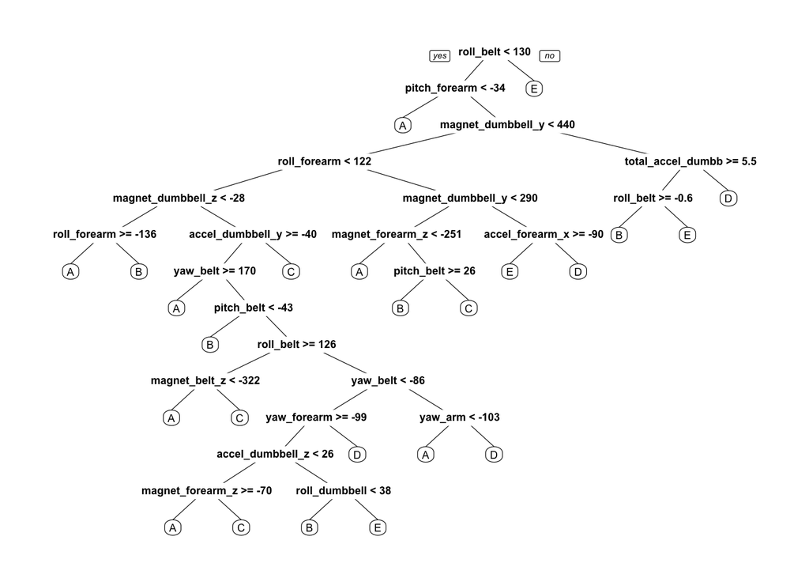

```r
mDT <- rpart(classe ~ ., data=trainingIn, method="class")
#plot(mDT)
#text(mDT, use.n=TRUE)
prp(mDT)
```

### Appendix: Random Forest number decision trees evaluation

```r
accDF <- data.frame(nTrees= numeric(0), Accuracy= numeric(0))
nList<-c(1,10,20,30,40,50)
for( i in 1:length(nList) ) {
  nTree<-nList[i]
  #print(paste(i, nTree))
  mRFx <- train(classe ~ ., data=trainingIn, method="rf",
                 trControl=trainControl(method="cv", 5),
                 ntree=nTree)
  #mRFx
  predictRF <- predict(mRFx, testingIn)
  confusionMatrix(testingIn$classe, predictRF)
  accuracy <- postResample(predictRF, testingIn$classe)
  accDF[i, ] <- c(nTree, accuracy)
}
accDF
```

```
##   nTrees  Accuracy
## 1      1 0.9354291
## 2     10 0.9881054
## 3     20 0.9915038
## 4     30 0.9926933
## 5     40 0.9928632
## 6     50 0.9923534
```

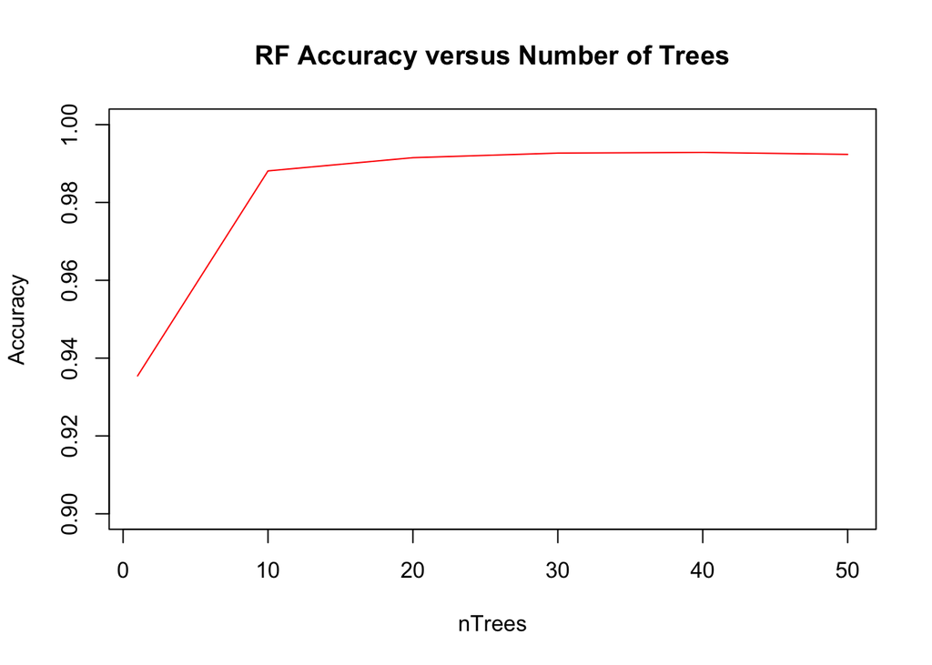

```r
plot(x=accDF$nTrees, y=accDF$Accuracy, type="l", main="RF Accuracy versus Number of Trees", xlab="nTrees", ylab="Accuracy", col="red", ylim=c(0.9,1.0))
```